# AllLifeBank_Sourojit_Dhua_AIML_ML_Project_full_code_notebook

### Decision Tree (Pre-pruning)

- **Note** - **I removed the class_weight="balanced" because I was getting way too many errors and false positives due to over-compensation. Re-running all models without this parameter again.**
- Hyperparameter tuning plays a critical role in optimizing model performance.
- Unlike model parameters, which are learned during training, hyperparameters must be set beforehand. Proper tuning enhances both the accuracy and robustness of the model.
- The loop below systematically iterates through predefined hyperparameter values to identify the optimal model based on the chosen evaluation metric, specifically the recall score.

```python
# Define the parameters of the tree to iterate over
max_depth_values = np.arange(2, 7, 2) # [2, 4, 6] Training 48 trees
max_leaf_nodes_values = [50, 75, 150, 250]
min_samples_split_values = [10, 30, 50, 70]

# Initialize variables to store the best model and its performance
best_estimator = None
best_score_diff = float('inf')
best_test_score = 0.0

# Iterate over all combinations of the specified parameter values
for max_depth in max_depth_values:
    for max_leaf_nodes in max_leaf_nodes_values:
        for min_samples_split in min_samples_split_values:

            # Initialize the tree with the current set of parameters
            estimator = DecisionTreeClassifier(
                max_depth=max_depth,
                max_leaf_nodes=max_leaf_nodes,
                min_samples_split=min_samples_split,
                random_state=42
            )

            # Fit the model to the training data
            estimator.fit(X_train, y_train)

            # Make predictions on the training and test sets
            y_train_pred = estimator.predict(X_train)
            y_test_pred = estimator.predict(X_test)

            # Calculate recall scores for training and test sets
            train_recall_score = recall_score(y_train, y_train_pred)
            test_recall_score = recall_score(y_test, y_test_pred)

            # Calculate the absolute difference between training and test recall scores
            score_diff = abs(train_recall_score - test_recall_score)

            # OLD
            # Update the best estimator and best score if the current one has a smaller score difference
            # if (score_diff < best_score_diff) & (test_recall_score > best_test_score):
            #  best_score_diff = score_diff
            #  best_test_score = test_recall_score
            #  best_estimator = estimator

            # NEW - Note* - made no difference from the old code above. I got the same Decision Tree depth.
            # Update the best estimator and best score if the current one has a smaller score difference

            # Based on feedback, removed the *(score_diff < best_score_diff)* Statement for best Recall value between train and test.
            if test_recall_score > best_test_score:
                best_score_diff = score_diff
                best_test_score = test_recall_score
                best_estimator = estimator

# Print the best parameters
print("Best parameters found:")
print(f"Max depth: {best_estimator.max_depth}")
print(f"Max leaf nodes: {best_estimator.max_leaf_nodes}")
print(f"Min samples split: {best_estimator.min_samples_split}")
print(f"Best test recall score: {best_test_score}")
```

```
Best parameters found:
Max depth: 6
Max leaf nodes: 50
Min samples split: 30
Best test recall score: 0.9097222222222222
```

- **Observations:**
- Before I removed class-weight=balanced, my Pre-Tuning best model max depth of 2 nodes. This seems very shallow to me and that it would not produce the best result but I'll stick with it here unrtil further analysis is done.
- After I removed the class-weight=balanced, my errors decreased and my max depth went to 6. I'll stick with this for now.

```python
# creating an instance of the best model
model2 = best_estimator

# fitting the best model to the training data
model2.fit(X_train, y_train)
```

```
DecisionTreeClassifier(max_depth=6, max_leaf_nodes=50, min_samples_split=30,
                       random_state=42)
```

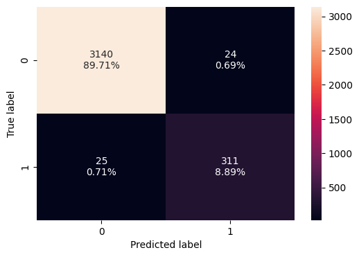

```python
confusion_matrix_sklearn(model2, X_train, y_train)
```

```python
decision_tree_tune_perf_train = model_performance_classification_sklearn(
    model2, X_train, y_train
)
decision_tree_tune_perf_train
```

|  | Accuracy | Recall | Precision | F1 |
| --- | --- | --- | --- | --- |
| 0 | 0.986 | 0.925595 | 0.928358 | 0.926975 |

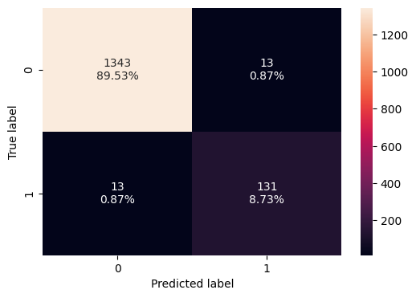

```python
confusion_matrix_sklearn(model2, X_test, y_test)
```

```python
decision_tree_tune_perf_test = model_performance_classification_sklearn(
    model2, X_test, y_test
)
decision_tree_tune_perf_test
```

|  | Accuracy | Recall | Precision | F1 |
| --- | --- | --- | --- | --- |
| 0 | 0.982667 | 0.909722 | 0.909722 | 0.909722 |

- **Observations:**
- The model is giving a generalized result now since the recall scores on both the train and test data are about 91 and 92 which shows that the model is able to generalize well on unseen data.

```python
feature_names = list(X_train.columns)
importances = model2.feature_importances_
indices = np.argsort(importances)
```

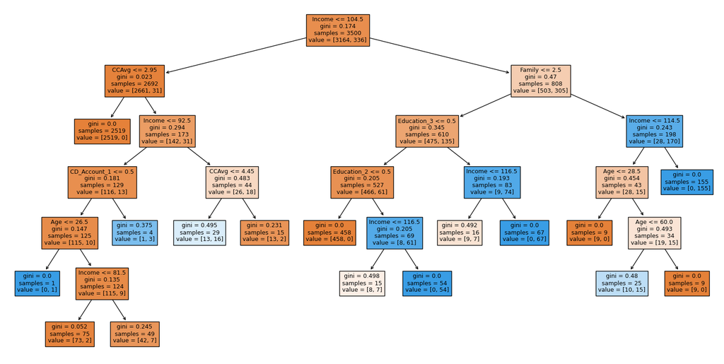

```python
plt.figure(figsize=(20, 10))
out = tree.plot_tree(
    model2,
    feature_names=feature_names,
    filled=True,
    fontsize=9,
    node_ids=False,
    class_names=None,
)
# below code will add arrows to the decision tree split if they are missing
for o in out:
    arrow = o.arrow_patch
    if arrow is not None:
        arrow.set_edgecolor("black")
        arrow.set_linewidth(1)
plt.show()
```

```python
# Text report showing the rules of a decision tree -
print(tree.export_text(model2, feature_names=feature_names, show_weights=True))
```

```
|--- Income <= 104.50
|   |--- CCAvg <= 2.95
|   |   |--- weights: [2519.00, 0.00] class: 0
|   |--- CCAvg >  2.95
|   |   |--- Income <= 92.50
|   |   |   |--- CD_Account_1 <= 0.50
|   |   |   |   |--- Age <= 26.50
|   |   |   |   |   |--- weights: [0.00, 1.00] class: 1
|   |   |   |   |--- Age >  26.50
|   |   |   |   |   |--- Income <= 81.50
|   |   |   |   |   |   |--- weights: [73.00, 2.00] class: 0
|   |   |   |   |   |--- Income >  81.50
|   |   |   |   |   |   |--- weights: [42.00, 7.00] class: 0
|   |   |   |--- CD_Account_1 >  0.50
|   |   |   |   |--- weights: [1.00, 3.00] class: 1
|   |   |--- Income >  92.50
|   |   |   |--- CCAvg <= 4.45
|   |   |   |   |--- weights: [13.00, 16.00] class: 1
|   |   |   |--- CCAvg >  4.45
|   |   |   |   |--- weights: [13.00, 2.00] class: 0
|--- Income >  104.50
|   |--- Family <= 2.50
|   |   |--- Education_3 <= 0.50
|   |   |   |--- Education_2 <= 0.50
|   |   |   |   |--- weights: [458.00, 0.00] class: 0
|   |   |   |--- Education_2 >  0.50
|   |   |   |   |--- Income <= 116.50
|   |   |   |   |   |--- weights: [8.00, 7.00] class: 0
|   |   |   |   |--- Income >  116.50
|   |   |   |   |   |--- weights: [0.00, 54.00] class: 1
|   |   |--- Education_3 >  0.50
|   |   |   |--- Income <= 116.50
|   |   |   |   |--- weights: [9.00, 7.00] class: 0
|   |   |   |--- Income >  116.50
|   |   |   |   |--- weights: [0.00, 67.00] class: 1
|   |--- Family >  2.50
|   |   |--- Income <= 114.50
|   |   |   |--- Age <= 28.50
|   |   |   |   |--- weights: [9.00, 0.00] class: 0
|   |   |   |--- Age >  28.50
|   |   |   |   |--- Age <= 60.00
|   |   |   |   |   |--- weights: [10.00, 15.00] class: 1
|   |   |   |   |--- Age >  60.00
|   |   |   |   |   |--- weights: [9.00, 0.00] class: 0
|   |   |--- Income >  114.50
|   |   |   |--- weights: [0.00, 155.00] class: 1
```

```python
importances = model2.feature_importances_
importances
```

```
array([0.0169584 , 0.39801898, 0.22280077, 0.02542859, 0.        ,
       0.        , 0.        , 0.        , 0.        , 0.        ,
       0.        , 0.17200677, 0.15840076, 0.        , 0.00638572,
       0.        , 0.        ])
```

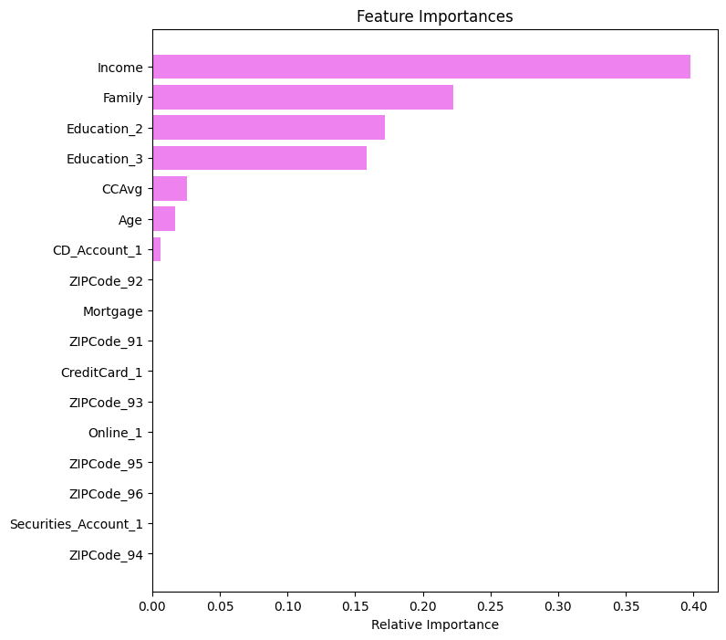

```python
# importance of features in the tree building

importances = model2.feature_importances_
indices = np.argsort(importances)

plt.figure(figsize=(8, 8))
plt.title("Feature Importances")
plt.barh(range(len(indices)), importances[indices], color="violet", align="center")
plt.yticks(range(len(indices)), [feature_names[i] for i in indices])
plt.xlabel("Relative Importance")
plt.show()
```

- **Observations:**
- In the pre-pruned decision tree, **Income**, **family size**, **Educaiton Level**, and **Credit Card Average** are the most important features.

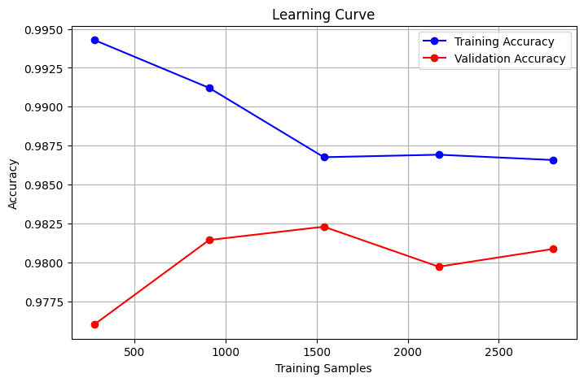

```python
# Import Learning Curve to double check how the model is learning between train and test.

from sklearn.model_selection import learning_curve

# Generate learning curve data
train_sizes, train_scores, test_scores = learning_curve(model2, X_train, y_train, cv=5, scoring="accuracy")

# Compute mean accuracy across cross-validation folds
train_mean = np.mean(train_scores, axis=1)
test_mean = np.mean(test_scores, axis=1)

# Plot learning curve
plt.figure(figsize=(8, 5))
plt.plot(train_sizes, train_mean, 'o-', label="Training Accuracy", color="blue")
plt.plot(train_sizes, test_mean, 'o-', label="Validation Accuracy", color="red")

# Labels and title
plt.xlabel("Training Samples")
plt.ylabel("Accuracy")
plt.title("Learning Curve")
plt.legend()
plt.grid()

# Show plot
plt.show()
```

- Observations from the learning curve graph above:
- The model seems to be a good fit to the data for the following reasons.
1. The **Training data** starts out high and gradually decreases as more data is introduced (as excpected).
2. The **Test data** starts out low and gradually increases then stabilizes more data is introduced (as excpected).
3. The Model has the right complexity to generalize well.
- **Removing class_weight=balanced seems to have provided for a better model.**

### Decision Tree (Post-pruning)

```python
clf = DecisionTreeClassifier(random_state=1)
path = clf.cost_complexity_pruning_path(X_train, y_train)
ccp_alphas, impurities = abs(path.ccp_alphas), path.impurities
```

```python
pd.DataFrame(path)
```

|  | ccp_alphas | impurities |
| --- | --- | --- |
| 0 | 0.000000 | 0.000000 |
| 1 | 0.000250 | 0.000500 |
| 2 | 0.000257 | 0.001014 |
| 3 | 0.000276 | 0.001566 |
| 4 | 0.000286 | 0.002137 |
| 5 | 0.000343 | 0.002480 |
| 6 | 0.000400 | 0.003680 |
| 7 | 0.000429 | 0.004109 |
| 8 | 0.000429 | 0.004537 |
| 9 | 0.000457 | 0.004995 |
| 10 | 0.000467 | 0.005461 |
| 11 | 0.000470 | 0.009222 |
| 12 | 0.000484 | 0.010189 |
| 13 | 0.000488 | 0.010677 |
| 14 | 0.000495 | 0.011667 |
| 15 | 0.000508 | 0.012175 |
| 16 | 0.000583 | 0.012758 |
| 17 | 0.000595 | 0.013354 |
| 18 | 0.000667 | 0.016023 |
| 19 | 0.000938 | 0.016961 |
| 20 | 0.000989 | 0.017950 |
| 21 | 0.000994 | 0.018944 |
| 22 | 0.001076 | 0.021097 |
| 23 | 0.001625 | 0.022723 |
| 24 | 0.001782 | 0.024505 |
| 25 | 0.001908 | 0.026413 |
| 26 | 0.002335 | 0.028748 |
| 27 | 0.002970 | 0.031718 |
| 28 | 0.008156 | 0.039874 |
| 29 | 0.025722 | 0.091318 |
| 30 | 0.034690 | 0.126007 |
| 31 | 0.047561 | 0.173568 |

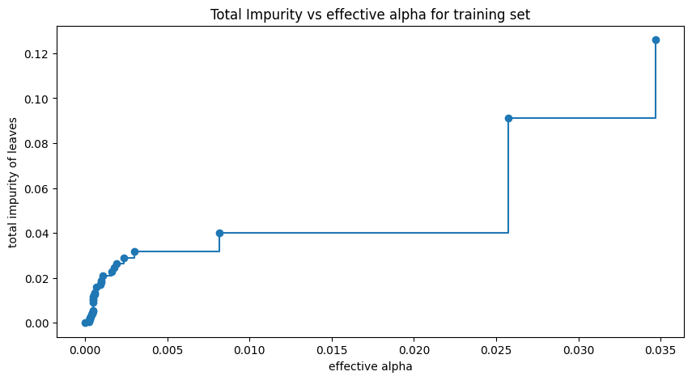

```python
fig, ax = plt.subplots(figsize=(10, 5))
ax.plot(ccp_alphas[:-1], impurities[:-1], marker="o", drawstyle="steps-post")
ax.set_xlabel("effective alpha")
ax.set_ylabel("total impurity of leaves")
ax.set_title("Total Impurity vs effective alpha for training set")
plt.show()
```

- **Observations:**
- As nodes are removed and impurity increases, I see ccp_alpha increases as well (as expected)

```python
clfs = []
for ccp_alpha in ccp_alphas:
    clf = DecisionTreeClassifier(
        random_state=1, ccp_alpha=ccp_alpha
    )
    clf.fit(X_train, y_train)
    clfs.append(clf)
print(
    "Number of nodes in the last tree is: {} with ccp_alpha: {}".format(
        clfs[-1].tree_.node_count, ccp_alphas[-1]
    )
)
```

```
Number of nodes in the last tree is: 1 with ccp_alpha: 0.04756053380018527
```

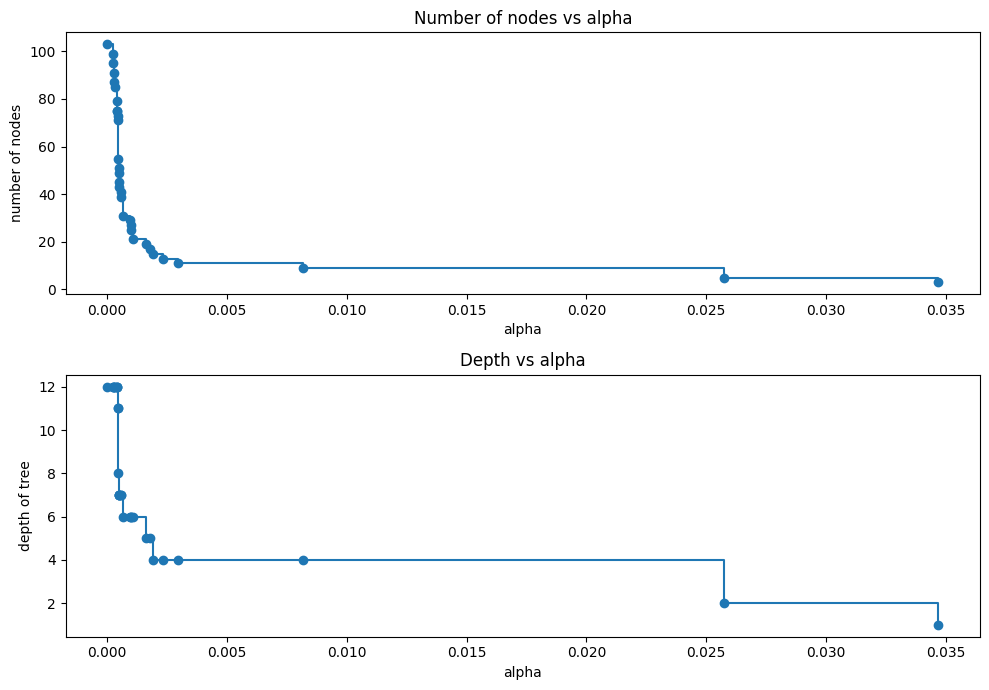

```python
clfs = clfs[:-1]
ccp_alphas = ccp_alphas[:-1]

node_counts = [clf.tree_.node_count for clf in clfs]
depth = [clf.tree_.max_depth for clf in clfs]
fig, ax = plt.subplots(2, 1, figsize=(10, 7))
ax[0].plot(ccp_alphas, node_counts, marker="o", drawstyle="steps-post")
ax[0].set_xlabel("alpha")
ax[0].set_ylabel("number of nodes")
ax[0].set_title("Number of nodes vs alpha")
ax[1].plot(ccp_alphas, depth, marker="o", drawstyle="steps-post")
ax[1].set_xlabel("alpha")
ax[1].set_ylabel("depth of tree")
ax[1].set_title("Depth vs alpha")
fig.tight_layout()
```

- **Observations:**
- Same for above - as we see the depth of the tree and number of nodes decrease we see ccp_alpha increase (as expected).

```python
recall_train = []
for clf in clfs:
    pred_train = clf.predict(X_train)
    values_train = recall_score(y_train, pred_train)
    recall_train.append(values_train)
```

```python
recall_test = []
for clf in clfs:
    pred_test = clf.predict(X_test)
    values_test = recall_score(y_test, pred_test)
    recall_test.append(values_test)
```

```python
train_scores = [clf.score(X_train, y_train) for clf in clfs]
test_scores = [clf.score(X_test, y_test) for clf in clfs]
```

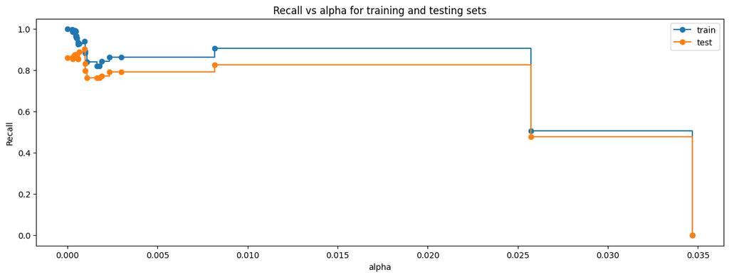

```python
fig, ax = plt.subplots(figsize=(15, 5))
ax.set_xlabel("alpha")
ax.set_ylabel("Recall")
ax.set_title("Recall vs alpha for training and testing sets")
ax.plot(
    ccp_alphas, recall_train, marker="o", label="train", drawstyle="steps-post",
)
ax.plot(ccp_alphas, recall_test, marker="o", label="test", drawstyle="steps-post")
ax.legend()
plt.show()
```

```python
# creating the model where we get highest train and test recall
index_best_model = np.argmax(recall_test)
best_model = clfs[index_best_model]
print(best_model)
```

```
DecisionTreeClassifier(ccp_alpha=0.0009377289377289376, random_state=1)
```

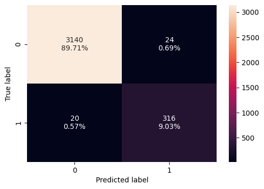

```python
model4 = best_model
confusion_matrix_sklearn(model4, X_train, y_train)
```

```python
decision_tree_post_perf_train = model_performance_classification_sklearn(
    model4, X_train, y_train
)
decision_tree_post_perf_train
```

|  | Accuracy | Recall | Precision | F1 |
| --- | --- | --- | --- | --- |
| 0 | 0.987429 | 0.940476 | 0.929412 | 0.934911 |

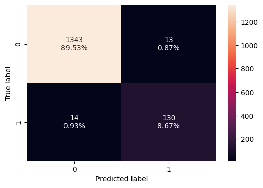

```python
confusion_matrix_sklearn(model4, X_test, y_test)
```

```python
decision_tree_post_test = model_performance_classification_sklearn(
    model4, X_test, y_test
)
decision_tree_post_test
```

|  | Accuracy | Recall | Precision | F1 |
| --- | --- | --- | --- | --- |
| 0 | 0.982 | 0.902778 | 0.909091 | 0.905923 |

- **Observations:**
- In the post-pruned tree also, the model is giving a generalized result since the recall scores on both the train and test data are coming to be around 94 and 90 respectively which shows that the model is able to generalize well on unseen data.

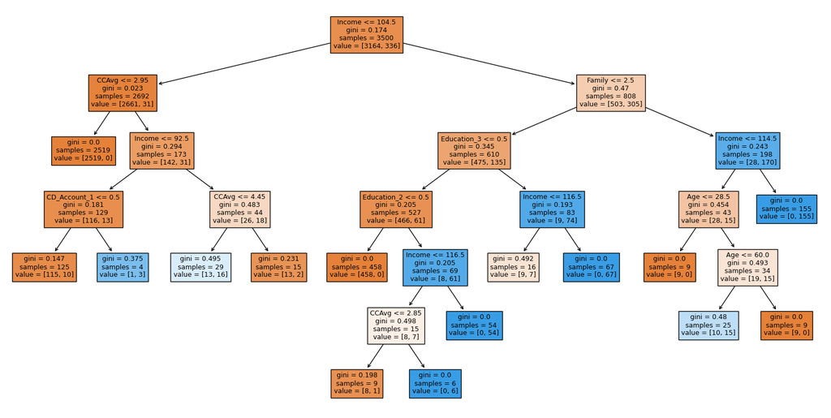

```python
plt.figure(figsize=(20, 10))

out = tree.plot_tree(
    model4,
    feature_names=feature_names,
    filled=True,
    fontsize=9,
    node_ids=False,
    class_names=None,
)
for o in out:
    arrow = o.arrow_patch
    if arrow is not None:
        arrow.set_edgecolor("black")
        arrow.set_linewidth(1)
plt.show()
```

```python
# Text report showing the rules of a decision tree -

print(tree.export_text(model4, feature_names=feature_names, show_weights=True))
```

```
|--- Income <= 104.50
|   |--- CCAvg <= 2.95
|   |   |--- weights: [2519.00, 0.00] class: 0
|   |--- CCAvg >  2.95
|   |   |--- Income <= 92.50
|   |   |   |--- CD_Account_1 <= 0.50
|   |   |   |   |--- weights: [115.00, 10.00] class: 0
|   |   |   |--- CD_Account_1 >  0.50
|   |   |   |   |--- weights: [1.00, 3.00] class: 1
|   |   |--- Income >  92.50
|   |   |   |--- CCAvg <= 4.45
|   |   |   |   |--- weights: [13.00, 16.00] class: 1
|   |   |   |--- CCAvg >  4.45
|   |   |   |   |--- weights: [13.00, 2.00] class: 0
|--- Income >  104.50
|   |--- Family <= 2.50
|   |   |--- Education_3 <= 0.50
|   |   |   |--- Education_2 <= 0.50
|   |   |   |   |--- weights: [458.00, 0.00] class: 0
|   |   |   |--- Education_2 >  0.50
|   |   |   |   |--- Income <= 116.50
|   |   |   |   |   |--- CCAvg <= 2.85
|   |   |   |   |   |   |--- weights: [8.00, 1.00] class: 0
|   |   |   |   |   |--- CCAvg >  2.85
|   |   |   |   |   |   |--- weights: [0.00, 6.00] class: 1
|   |   |   |   |--- Income >  116.50
|   |   |   |   |   |--- weights: [0.00, 54.00] class: 1
|   |   |--- Education_3 >  0.50
|   |   |   |--- Income <= 116.50
|   |   |   |   |--- weights: [9.00, 7.00] class: 0
|   |   |   |--- Income >  116.50
|   |   |   |   |--- weights: [0.00, 67.00] class: 1
|   |--- Family >  2.50
|   |   |--- Income <= 114.50
|   |   |   |--- Age <= 28.50
|   |   |   |   |--- weights: [9.00, 0.00] class: 0
|   |   |   |--- Age >  28.50
|   |   |   |   |--- Age <= 60.00
|   |   |   |   |   |--- weights: [10.00, 15.00] class: 1
|   |   |   |   |--- Age >  60.00
|   |   |   |   |   |--- weights: [9.00, 0.00] class: 0
|   |   |--- Income >  114.50
|   |   |   |--- weights: [0.00, 155.00] class: 1
```

```python
importances = model4.feature_importances_
indices = np.argsort(importances)
```

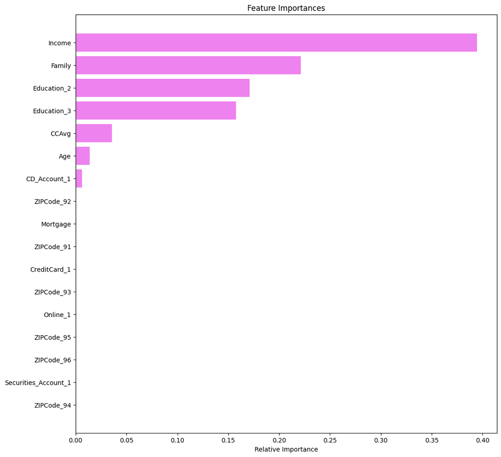

```python
plt.figure(figsize=(12, 12))
plt.title("Feature Importances")
plt.barh(range(len(indices)), importances[indices], color="violet", align="center")
plt.yticks(range(len(indices)), [feature_names[i] for i in indices])
plt.xlabel("Relative Importance")
plt.show()
```

- **Observations:**
- In the post-pruned tree, it appears the most important features are: **Income**, **Family Size, Education Level**, and **Credit Card Average**.

## Model Performance Comparison and Final Model Selection

```python
# training performance comparison

models_train_comp_df = pd.concat(
    [
        decision_tree_default_perf_train.T,
        decision_tree_perf_train.T,
        decision_tree_tune_perf_train.T,
        decision_tree_post_perf_train.T,
    ],
    axis=1,
)
models_train_comp_df.columns = [
    "Decision Tree (sklearn default)",
    "Decision Tree with class_weight",
    "Decision Tree (Pre-Pruning)",
    "Decision Tree (Post-Pruning)",
]
print("Training performance comparison:")
models_train_comp_df
```

```
Training performance comparison:
```

|  | Decision Tree (sklearn default) | Decision Tree with class_weight | Decision Tree (Pre-Pruning) | Decision Tree (Post-Pruning) |
| --- | --- | --- | --- | --- |
| Accuracy | 1.0 | 1.0 | 0.986000 | 0.987429 |
| Recall | 1.0 | 1.0 | 0.925595 | 0.940476 |
| Precision | 1.0 | 1.0 | 0.928358 | 0.929412 |
| F1 | 1.0 | 1.0 | 0.926975 | 0.934911 |

```python
# testing performance comparison

models_test_comp_df = pd.concat(
    [
        decision_tree_default_perf_test.T,
        decision_tree_perf_test.T,
        decision_tree_tune_perf_test.T,
        decision_tree_post_test.T,
    ],
    axis=1,
)
models_test_comp_df.columns = [
    "Decision Tree (sklearn default)",
    "Decision Tree with class_weight",
    "Decision Tree (Pre-Pruning)",
    "Decision Tree (Post-Pruning)",
]
print("Test set performance comparison:")
models_test_comp_df
```

```
Test set performance comparison:
```

|  | Decision Tree (sklearn default) | Decision Tree with class_weight | Decision Tree (Pre-Pruning) | Decision Tree (Post-Pruning) |
| --- | --- | --- | --- | --- |
| Accuracy | 0.982000 | 0.982000 | 0.982667 | 0.982000 |
| Recall | 0.861111 | 0.881944 | 0.909722 | 0.902778 |
| Precision | 0.946565 | 0.927007 | 0.909722 | 0.909091 |
| F1 | 0.901818 | 0.903915 | 0.909722 | 0.905923 |

- **Observations:**
- The Decision tree model with pre-pruning is giving highest recall scores on the test data set.
- Therefore, we are choosing the **pre-pruned tree as our best model**.

## Actionable Insights and Business Recommendations

1️⃣ **High-Income Customers Are More Likely to Accept Loans**

- **Observation:** Our models indicate a strong correlation between **income level and loan acceptance**.
- **Recommendation:**
- Target high-income individuals with personalized loan offers.

2️⃣ **Customers with Higher Credit Card Spending Tend to Accept Loans**

3️⃣ **Education Level Affects Loan Acceptance**

- **Observation:** Customers with **higher education levels (Graduate & Advanced degrees) are more likely to accept loans**.
- **Recommendation:**
- Prioritize targeted marketing for professionals with graduate and postgraduate degrees.

4️⃣ **Large Family Size Increases Loan Acceptance**

- **Observation:** Customers with **larger families (3-4 members)** tend to **accept loans more frequently**.
- **Recommendation:**
- **Introduce family-focused loan programs**, such as **education loans, home renovation loans, or vacation financing**.
- **Create targeted email & digital campaigns** for customers with **families**.

```python
# Converting notebook to .html format for upload:

!jupyter nbconvert --to html '/content/drive/MyDrive/Colab Notebooks/AllLifeBank_Sourojit_Dhua_AIML_ML_Project_full_code_notebook.ipynb'
```

```
[NbConvertApp] Converting notebook /content/drive/MyDrive/Colab Notebooks/AllLifeBank_Sourojit_Dhua_AIML_ML_Project_full_code_notebook.ipynb to html
[NbConvertApp] WARNING | Alternative text is missing on 44 image(s).
[NbConvertApp] Writing 2962745 bytes to /content/drive/MyDrive/Colab Notebooks/AllLifeBank_Sourojit_Dhua_AIML_ML_Project_full_code_notebook.html
```